# Peer Graded Assignment

## Background

Using devices such as Jawbone Up, Nike FuelBand, and Fitbit it is now possible to collect a large amount of data about personal activity relatively inexpensively. These type of devices are part of the quantified self movement - a group of enthusiasts who take measurements about themselves regularly to improve their health, to find patterns in their behavior, or because they are tech geeks. One thing that people regularly do is quantify how much of a particular activity they do, but they rarely quantify how well they do it. In this project, your goal will be to use data from accelerometers on the belt, forearm, arm, and dumbell of 6 participants.

## Data Loading

The training data for this project are available here:

https://d396qusza40orc.cloudfront.net/predmachlearn/pml-training.csv

The test data are available here:

https://d396qusza40orc.cloudfront.net/predmachlearn/pml-testing.csv

The data for this project come from http://groupware.les.inf.puc-rio.br/har. Full source:

Velloso, E.; Bulling, A.; Gellersen, H.; Ugulino, W.; Fuks, H. “Qualitative Activity Recognition of Weight Lifting Exercises. Proceedings of 4th International Conference in Cooperation with SIGCHI (Augmented Human ’13)”. Stuttgart, Germany: ACM SIGCHI, 2013.

My special thanks to the above mentioned authors for being so generous in allowing their data to be used for this kind of assignment.

```r
training<-read.csv("pml-training.csv",header = TRUE)
testing  <- read.csv("pml-testing.csv", header= TRUE)
```

## Overview about Data

“Six young health participants were asked to perform one set of 10 repetitions of the Unilateral Dumbbell Biceps Curl in five different fashions: exactly according to the specification (Class A), throwing the elbows to the front (Class B), lifting the dumbbell only halfway (Class C), lowering the dumbbell only halfway (Class D) and throwing the hips to the front (Class E).

Class A corresponds to the specified execution of the exercise, while the other 4 classes correspond to common mistakes. Participants were supervised by an experienced weight lifter to make sure the execution complied to the manner they were supposed to simulate. The exercises were performed by six male participants aged between 20-28 years, with little weight lifting experience. We made sure that all participants could easily simulate the mistakes in a safe and controlled manner by using a relatively light dumbbell (1.25kg)."

## Creating Training and Test set

```r
library(caret)
library(rpart.plot)
library(randomForest)
library(e1071)
library(rpart)
library(rattle)
library(plyr)
library(doSNOW)
dim(training)
```

```
## [1] 19622   160
```

```r
str(training,list.len=15)
```

```
## 'data.frame':    19622 obs. of  160 variables:
##  $ X                       : int  1 2 3 4 5 6 7 8 9 10 ...
##  $ user_name               : Factor w/ 6 levels "adelmo","carlitos",..: 2 2 2 2 2 2 2 2 2 2 ...
##  $ raw_timestamp_part_1    : int  1323084231 1323084231 1323084231 1323084232 1323084232 1323084232 1323084232 1323084232 1323084232 1323084232 ...
##  $ raw_timestamp_part_2    : int  788290 808298 820366 120339 196328 304277 368296 440390 484323 484434 ...
##  $ cvtd_timestamp          : Factor w/ 20 levels "02/12/2011 13:32",..: 9 9 9 9 9 9 9 9 9 9 ...
##  $ new_window              : Factor w/ 2 levels "no","yes": 1 1 1 1 1 1 1 1 1 1 ...
##  $ num_window              : int  11 11 11 12 12 12 12 12 12 12 ...
##  $ roll_belt               : num  1.41 1.41 1.42 1.48 1.48 1.45 1.42 1.42 1.43 1.45 ...
##  $ pitch_belt              : num  8.07 8.07 8.07 8.05 8.07 8.06 8.09 8.13 8.16 8.17 ...
##  $ yaw_belt                : num  -94.4 -94.4 -94.4 -94.4 -94.4 -94.4 -94.4 -94.4 -94.4 -94.4 ...
##  $ total_accel_belt        : int  3 3 3 3 3 3 3 3 3 3 ...
##  $ kurtosis_roll_belt      : Factor w/ 397 levels "","-0.016850",..: 1 1 1 1 1 1 1 1 1 1 ...
##  $ kurtosis_picth_belt     : Factor w/ 317 levels "","-0.021887",..: 1 1 1 1 1 1 1 1 1 1 ...
##  $ kurtosis_yaw_belt       : Factor w/ 2 levels "","#DIV/0!": 1 1 1 1 1 1 1 1 1 1 ...
##  $ skewness_roll_belt      : Factor w/ 395 levels "","-0.003095",..: 1 1 1 1 1 1 1 1 1 1 ...
##   [list output truncated]
```

```r
cl<-makeCluster(8, type="SOCK")
registerDoSNOW(cl)
set.seed(2468)
inTrain<-createDataPartition(training$classe, p=0.6,list=FALSE)
trainset<-training[inTrain,]
testset<-training[-inTrain,]
dim(trainset)
```

```
## [1] 11776   160
```

## Cleaning of Data

As the trainset has 160 variables we have to pre process it.So, let’s remove all the columns having just NA values.After that we can remove the variables with no variability, that can be tested by Near Zero Variance function.

```r
na<-sapply(training, function(x) sum(is.na(x))>7800)
trainset<-trainset[,!na]
testset<-testset[,!na]
dim(trainset)
```

```
## [1] 11776    93
```

```r
nzv<-nearZeroVar(trainset)
trainset<-trainset[,-nzv]
testset<-testset[,-nzv]
dim(trainset)
```

```
## [1] 11776    59
```

Now we are left with 59 variables, and we can remove the starting colums that are just for information purpose.

```r
trainset <- trainset[, -(1:5)]
testset  <- testset[, -(1:5)]
dim(trainset)
```

```
## [1] 11776    54
```

## Correlation Analysis

Using cor function we can calculate correlation between all the variables except the outcome variable.

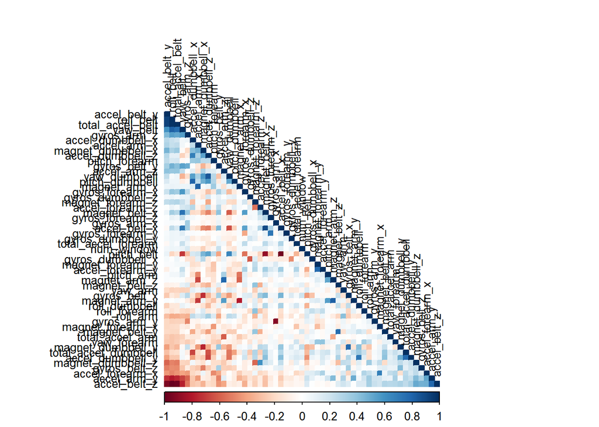

```r
cl<-makeCluster(8, type="SOCK")
registerDoSNOW(cl)
library(corrplot)
corMatrix <- cor(trainset[, -54])
corrplot(corMatrix, order = "FPC", method = "color", type = "lower",
         tl.cex = 0.8, tl.col = rgb(0, 0, 0))
```

```r
stopCluster(cl)
```

## Predicition Model Building

I would like to test three models i.e. RandomForest, decision tree and generalized boosted model on the trainset and use it to predict values in testset and check the overall accuracy of it.

### a) Random Forest

```r
cl<-makeCluster(8, type="SOCK")
registerDoSNOW(cl)
set.seed(12345)
controlRF <- trainControl(method="cv", number=3, verboseIter=FALSE)
modFitRF <- train(classe ~ ., data=trainset, method="rf",
                          trControl=controlRF)
modFitRF$finalModel
```

```
##
## Call:
##  randomForest(x = x, y = y, mtry = param$mtry)
##                Type of random forest: classification
##                      Number of trees: 500
## No. of variables tried at each split: 27
##
##         OOB estimate of  error rate: 0.35%
## Confusion matrix:
##      A    B    C    D    E class.error
## A 3348    0    0    0    0 0.000000000
## B    8 2265    6    0    0 0.006143045
## C    0    5 2049    0    0 0.002434275
## D    0    0   13 1916    1 0.007253886
## E    0    1    0    7 2157 0.003695150
```

```r
varImp(modFitRF)
```

```
## rf variable importance
##
##   only 20 most important variables shown (out of 53)
##
##                      Overall
## num_window           100.000
## roll_belt             68.938
## pitch_forearm         41.759
## yaw_belt              34.206
## magnet_dumbbell_z     31.572
## magnet_dumbbell_y     30.894
## pitch_belt            27.507
## roll_forearm          26.121
## accel_dumbbell_y      14.804
## accel_forearm_x       11.650
## roll_dumbbell         11.575
## magnet_dumbbell_x     10.774
## total_accel_dumbbell   9.771
## accel_belt_z           9.573
## accel_dumbbell_z       9.128
## magnet_belt_z          7.358
## magnet_forearm_z       7.297
## magnet_belt_y          7.140
## magnet_belt_x          6.479
## roll_arm               5.496
```

```r
predictRF <- predict(modFitRF, newdata=testset)
confMatRF <- confusionMatrix(predictRF, testset$classe)
confMatRF
```

```
## Confusion Matrix and Statistics
##
##           Reference
## Prediction    A    B    C    D    E
##          A 2230    3    0    0    0
##          B    1 1512    5    0    0
##          C    0    2 1363    7    0
##          D    0    1    0 1278    2
##          E    1    0    0    1 1440
##
## Overall Statistics
##
##                Accuracy : 0.9971
##                  95% CI : (0.9956, 0.9981)
##     No Information Rate : 0.2845
##     P-Value [Acc > NIR] : < 2.2e-16
##
##                   Kappa : 0.9963
##  Mcnemar's Test P-Value : NA
##
## Statistics by Class:
##
##                      Class: A Class: B Class: C Class: D Class: E
## Sensitivity            0.9991   0.9960   0.9963   0.9938   0.9986
## Specificity            0.9995   0.9991   0.9986   0.9995   0.9997
## Pos Pred Value         0.9987   0.9960   0.9934   0.9977   0.9986
## Neg Pred Value         0.9996   0.9991   0.9992   0.9988   0.9997
## Prevalence             0.2845   0.1935   0.1744   0.1639   0.1838
## Detection Rate         0.2842   0.1927   0.1737   0.1629   0.1835
## Detection Prevalence   0.2846   0.1935   0.1749   0.1633   0.1838
## Balanced Accuracy      0.9993   0.9975   0.9975   0.9967   0.9992
```

```r
stopCluster(cl)
```

##### So the overall accuracy we are getting from RandomForest model is 99.71%.

### b) Generalized Boosted Model

```r
cl<-makeCluster(8, type="SOCK")
registerDoSNOW(cl)
set.seed(12345)
controlGBM <- trainControl(method = "repeatedcv", number = 5, repeats = 1)
modFitGBM  <- train(classe ~ ., data=trainset, method = "gbm",
                    trControl = controlGBM, verbose = FALSE)
modFitGBM$finalModel
```

```
## A gradient boosted model with multinomial loss function.
## 150 iterations were performed.
## There were 53 predictors of which 45 had non-zero influence.
```

```r
predictGBM <- predict(modFitGBM, newdata=testset)
confMatGBM <- confusionMatrix(predictGBM, testset$classe)
confMatGBM
```

```
## Confusion Matrix and Statistics
##
##           Reference
## Prediction    A    B    C    D    E
##          A 2229   18    0    0    1
##          B    3 1477   20    7    8
##          C    0   17 1339   16    1
##          D    0    5    8 1262    8
##          E    0    1    1    1 1424
##
## Overall Statistics
##
##                Accuracy : 0.9853
##                  95% CI : (0.9824, 0.9879)
##     No Information Rate : 0.2845
##     P-Value [Acc > NIR] : < 2.2e-16
##
##                   Kappa : 0.9815
##  Mcnemar's Test P-Value : NA
##
## Statistics by Class:
##
##                      Class: A Class: B Class: C Class: D Class: E
## Sensitivity            0.9987   0.9730   0.9788   0.9813   0.9875
## Specificity            0.9966   0.9940   0.9948   0.9968   0.9995
## Pos Pred Value         0.9915   0.9749   0.9752   0.9836   0.9979
## Neg Pred Value         0.9995   0.9935   0.9955   0.9963   0.9972
## Prevalence             0.2845   0.1935   0.1744   0.1639   0.1838
## Detection Rate         0.2841   0.1882   0.1707   0.1608   0.1815
## Detection Prevalence   0.2865   0.1931   0.1750   0.1635   0.1819
## Balanced Accuracy      0.9976   0.9835   0.9868   0.9891   0.9935
```

```r
stopCluster(cl)
```

### c) Decision Tree

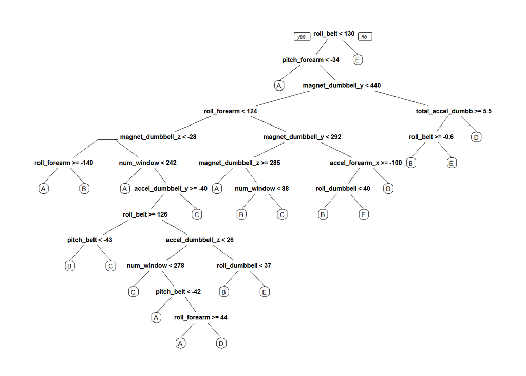

```r
set.seed(12345)
modFitDecTree <- rpart(classe ~ ., data=trainset, method="class")
prp(modFitDecTree)
```

```r
predictDecTree <- predict(modFitDecTree, newdata=testset, type="class")
confMatDecTree <- confusionMatrix(predictDecTree, testset$classe)
confMatDecTree
```

```
## Confusion Matrix and Statistics
##
##           Reference
## Prediction    A    B    C    D    E
##          A 2067  294   64   93  100
##          B   74  905   48  105  156
##          C   14  109 1095  187  100
##          D   48   96   73  741   66
##          E   29  114   88  160 1020
##
## Overall Statistics
##
##                Accuracy : 0.7428
##                  95% CI : (0.733, 0.7524)
##     No Information Rate : 0.2845
##     P-Value [Acc > NIR] : < 2.2e-16
##
##                   Kappa : 0.6725
##  Mcnemar's Test P-Value : < 2.2e-16
##
## Statistics by Class:
##
##                      Class: A Class: B Class: C Class: D Class: E
## Sensitivity            0.9261   0.5962   0.8004  0.57621   0.7074
## Specificity            0.9019   0.9395   0.9367  0.95686   0.9389
## Pos Pred Value         0.7895   0.7026   0.7276  0.72363   0.7229
## Neg Pred Value         0.9684   0.9065   0.9569  0.92011   0.9344
## Prevalence             0.2845   0.1935   0.1744  0.16391   0.1838
## Detection Rate         0.2634   0.1153   0.1396  0.09444   0.1300
## Detection Prevalence   0.3337   0.1642   0.1918  0.13051   0.1798
## Balanced Accuracy      0.9140   0.7678   0.8686  0.76653   0.8231
```

## Final Model Prediction on Test Data

```r
predictTEST <- predict(modFitRF, newdata=testing)
predictTEST
```

```
##  [1] B A B A A E D B A A B C B A E E A B B B
## Levels: A B C D E
```

Now let’s make a data frame containing the test result and the result obtained from our model.

```r
testing$classe <- predictTEST
submit <- data.frame(problem_id = testing$problem_id, classe = predictTEST)
write.csv(submit, file = "Course-Project-Prediction-Quiz.csv", row.names = FALSE)
```